# act_report

## Report: act_report

## Insights and Visualisations

We obtained the following insights from our analysis:

1. `pupper` has the most retweets and favourites however, it is important to note that a large number of tweets don't have any mention of the dog stage and so are excluded from this result.
2. The image classifier was most confident with its scoring of komondor dogs, however there were only 3 of these dogs. A pug seems to have the best prediction while of the top 10 who are also on the top 10 most listed dogs.
3. `Cooper` is the most common dog name.
4. 74% of dogs with retweets, favourite and image classifications were classified as dogs using the P1 classifier, i.e. the strongest prediction yielded a result of dog for 74% of the tweets.
5. 15.5% of tweets that went through the classifier didnt get any dog predictions.
6. Scottish_deerhound had the lowest prediction rate for P1 as 18.2%

In addition, we produced this visualisation showing the retweet and favourite count by dog stage

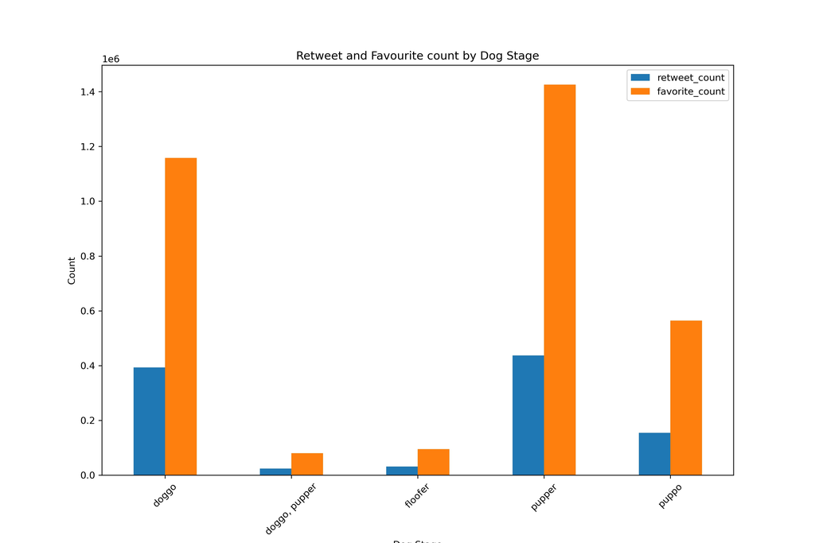

```python
from IPython import display
display.Image("./count_by_dog_stage.jpg")
```